# Pratchett et al 2020: Temporal and Spatial Dynamics of Butterflyfish populations at Lizard Island 1995-2020

Samuel Matthews

18 February 2020

This analysis will focus on the temporal and habitat trends of Buttterfy fish populations.

1. Temporal trends in Total Fish abundance, richness evenness across habaitat types
2. Fish Community Composition trends across time
3. Identification of Specialist/Generalist species across habitats
4. Coral Community Analysis

# 1. Temporal trends

## Diversity and Richness Indicies by Habitat

First job is to calcualte, richness (RICHNESS.MAR), diversity (SHANNON) evenness (PILOU EVEN), and total abundance with respect to different habitats.

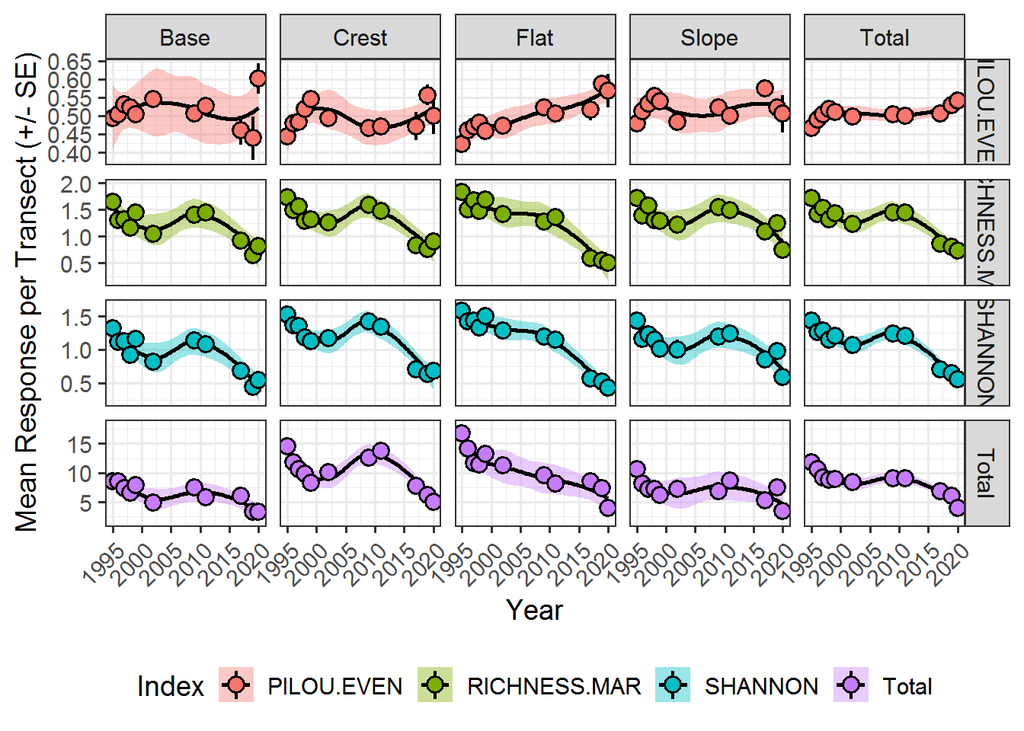

```r
p5
```

## Mean Abundance by Habitat and Diet.

Now we’ll look at how mean abundance changes with repect to habitat for each of the feeding groups. THis same plot could be easily reporduced for any of the other indicies

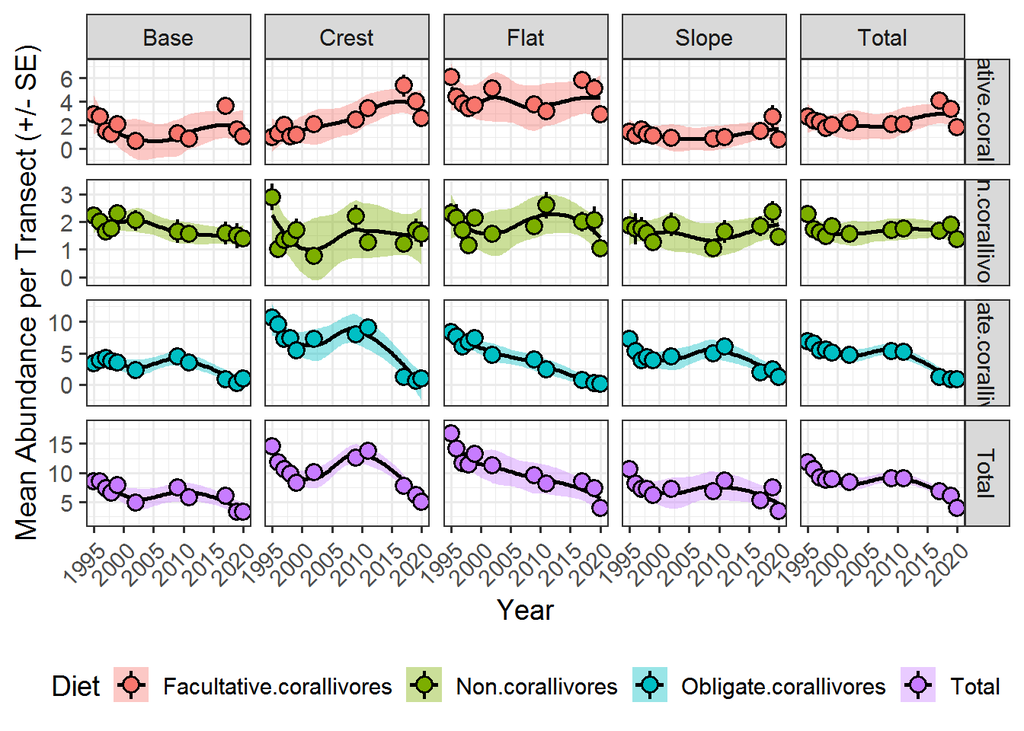

```r
p7
```

# 2. Fish Community Analysis

- THis section needs quite a bit of work as there aren’t many clear patterns I can make out. It looks like the crest and base communities separate out quite nicely and it looks as the slope and base habitats have changed in 2019-20. I’m looking inot to how best analyse community data as a time series, to quantify when the community has shifted significantly. It might be a matter of comparing years where coral cover was low vs high.
- I would also like to look produce similar figures but aggregated up for the feeding groups.

```r
pHull =ggplot() +
  geom_polygon(data=hull.data,aes(x=NMDS1,y=NMDS2,fill=grp,group=grp),alpha=0.30) + # add the convex hulls
  geom_point(data=data.scores,aes(x=NMDS1,y=NMDS2,shape=grp,colour=grp),size=3) + # add the point markers
  # geom_label(data=species.scores,aes(x=NMDS1,y=NMDS2,label=species),alpha=0.5) +  # add the species labels
  scale_colour_manual(labels = levels(butt.samp2$zone), values=c( "seagreen", "orange", "lightblue", "purple")) +
  scale_fill_manual(labels = levels(butt.samp2$zone),values=c( "seagreen", "orange", "lightblue", "purple")) +
  scale_shape_manual(labels = levels(butt.samp2$zone), values = 16:19) +
  coord_equal() +
  guides(fill=guide_legend(title="Habitat", reverse =T)) +
  guides(color=guide_legend(title="Habitat", reverse =T)) +
  guides(shape=guide_legend(title="Habitat", reverse =T)) +
  # geom_rect(aes(ymin = 0.75, ymax = 0.95, xmin = 0.55, xmax = 0.99), fill= "white", color = "black") +
  # annotate(geom="text", x=0.99, y=0.9, label="Stress = 0.099", hjust=1) +
  # annotate(geom="text", x=0.99, y=0.83, label="R = 0.863", hjust=1) +
  # annotate(geom="text", x=0.99, y=0.76, label="P = 0.001", hjust=1) +
  theme_bw(base_size=14) +
  # ggtitle("(b)")+
  theme(axis.text.x = element_blank(),  # remove x-axis text
        axis.text.y = element_blank(), # remove y-axis text
        axis.ticks = element_blank(),  # remove axis ticks
        legend.position = "top",
        # axis.title.x = element_text(size=18), # remove x-axis labels
        # axis.title.y = element_text(size=18), # remove y-axis labels
        panel.background = element_blank(),
        panel.grid.major = element_blank(),  #remove major-grid labels
        panel.grid.minor = element_blank(),  #remove minor-grid labels
        plot.background = element_blank()) +
  facet_grid(yr~location)

pHull2 =ggplot() +
  geom_polygon(data=hull.data,aes(x=NMDS1,y=NMDS2,fill=grp,group=grp),alpha=0.30) + # add the convex hulls
  geom_point(data=data.scores,aes(x=NMDS1,y=NMDS2,shape=grp,colour=grp),size=4) + # add the point markers
  # geom_label(data=species.scores,aes(x=NMDS1,y=NMDS2,label=species),alpha=0.5) +  # add the species labels
  scale_colour_manual(labels = levels(butt.samp2$zone), values=c( "seagreen", "orange", "lightblue", "purple")) +
  scale_fill_manual(labels = levels(butt.samp2$zone),values=c( "seagreen", "orange", "lightblue", "purple")) +
  scale_shape_manual(labels = levels(butt.samp2$zone), values = 16:19) +
  coord_equal() +
  guides(fill=guide_legend(title="Habitat", reverse =T)) +
  guides(color=guide_legend(title="Habitat", reverse =T)) +
  guides(shape=guide_legend(title="Habitat", reverse =T)) +
  # geom_rect(aes(ymin = 0.75, ymax = 0.95, xmin = 0.55, xmax = 0.99), fill= "white", color = "black") +
  # annotate(geom="text", x=0.99, y=0.9, label="Stress = 0.099", hjust=1) +
  # annotate(geom="text", x=0.99, y=0.83, label="R = 0.863", hjust=1) +
  # annotate(geom="text", x=0.99, y=0.76, label="P = 0.001", hjust=1) +
  theme_bw(base_size=14) +
  # ggtitle("(b)")+
  theme(axis.text.x = element_blank(),  # remove x-axis text
        axis.text.y = element_blank(), # remove y-axis text
        axis.ticks = element_blank(),  # remove axis ticks
        legend.position = "top",
        # axis.title.x = element_text(size=18), # remove x-axis labels
        # axis.title.y = element_text(size=18), # remove y-axis labels
        panel.background = element_blank(),
        panel.grid.major = element_blank(),  #remove major-grid labels
        panel.grid.minor = element_blank(),  #remove minor-grid labels
        plot.background = element_blank()) +
  facet_wrap(~yr, nrow = 2)

# ggsave(plot = pHull, file="Community.png",dpi=300, height=12, width=6)
# ggsave(plot = pHull2, file="Community2.png",dpi=300, height=10, width=10)
# butt.simp = simper(butt.faun2, group = butt.samp2$zone)
# summary(butt.simp)
```

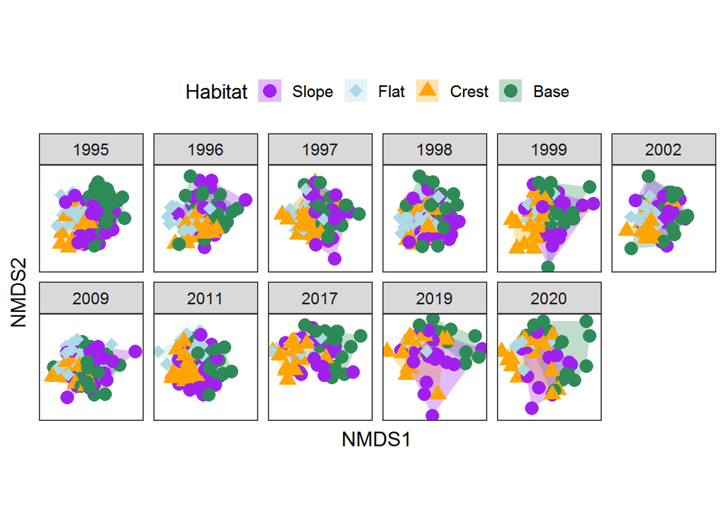

```r
pHull2
```

# 3. Habitat Generalists vs Specialists

Here we use Similarity Percentages (SIMPER) to rank the contribution of each species to the differences found between groups. The two factors I have investigated are habitat and site, but we could also quie easily group years of high coral/low coral cover together to see which species contribute the most to differences between year groups. SIMPER doesn’t indicate whether or not these species are abundant or rare, or specialists vs generalists, but it says which species we could use to tell different group apart.

THe second approach is to use indicative species analysis to identiy species associated with certain habiats or sites. Species indicative of only 1 /group would be more specialist while species indicative of multiple sites/habitats would be more generalist.

THere is more to be done on this but this gives a pretty good indication.

```r
butt.simp.zone = simper(butt.faun2, group = butt.samp2$zone)
butt.simp.site = simper(butt.faun2, group = butt.samp2$site)
butt.simp.year = simper(butt.faun2, group = butt.samp2$Year)
# summary(butt.simp.year)
```

## Similarity Percentages (SIMPER) by Habitat

```r
summary(butt.simp.zone)
```

```
##
## Contrast: Flat_Crest
##
##                         average       sd   ratio      ava      avb cumsum
## FC...C.citrinellus    0.1621034 0.129187 1.25480 3.929204 1.938053 0.2366
## OC...C.baronessa      0.1162010 0.110516 1.05144 0.827434 2.584071 0.4062
## OC...C.lunulatus      0.1052202 0.093676 1.12323 1.814159 2.048673 0.5598
## NC...C.vagabundus     0.0750569 0.074940 1.00157 1.407080 1.017699 0.6694
## OC...C.trifascialis   0.0481245 0.061247 0.78575 0.451327 0.907080 0.7396
## OC...C.plebeius       0.0344857 0.054235 0.63585 0.694690 0.234513 0.7900
## NC...C.auriga         0.0245225 0.046988 0.52189 0.283186 0.274336 0.8258
## FC...C.ephippium      0.0216213 0.040332 0.53609 0.230088 0.296460 0.8573
## OC...C.rainfordi      0.0213748 0.042923 0.49797 0.349558 0.159292 0.8885
## SC...C.melannotus     0.0193301 0.037330 0.51781 0.256637 0.203540 0.9167
## NC...C.rafflesi       0.0140938 0.035694 0.39485 0.141593 0.194690 0.9373
## FC...C.kleinii        0.0119517 0.032643 0.36614 0.159292 0.097345 0.9548
## SC...C.unimaculatus   0.0109751 0.030894 0.35525 0.088496 0.168142 0.9708
## OC...C.aureofasciatus 0.0063454 0.020850 0.30433 0.039823 0.119469 0.9800
## NC...C.lineolatus     0.0049190 0.020507 0.23988 0.026549 0.075221 0.9872
## NC...C.lunula         0.0038772 0.016773 0.23115 0.026549 0.061947 0.9929
## FC...C.ulientensis    0.0025735 0.013201 0.19495 0.022124 0.030973 0.9966
## FC...C.speculum       0.0014839 0.011942 0.12426 0.030973 0.008850 0.9988
## OC...C.pelewensis     0.0003786 0.004132 0.09163 0.004425 0.004425 0.9994
## NC...C.flavirostris   0.0002557 0.003995 0.06400 0.000000 0.004425 0.9997
## NC...C.semion         0.0001814 0.002777 0.06531 0.004425 0.000000 1.0000
## OC...C.bennetti       0.0000000 0.000000     NaN 0.000000 0.000000 1.0000
## FC...C.mertensii      0.0000000 0.000000     NaN 0.000000 0.000000 1.0000
##
## Contrast: Flat_Slope
##
##                         average       sd   ratio      ava      avb cumsum
## FC...C.citrinellus    0.2138903 0.149901 1.42687 3.929204 0.540084 0.2790
## OC...C.lunulatus      0.1163574 0.104706 1.11128 1.814159 1.831224 0.4308
## NC...C.vagabundus     0.0871396 0.086601 1.00622 1.407080 1.126582 0.5444
## OC...C.baronessa      0.0706870 0.086442 0.81774 0.827434 0.966245 0.6366
## OC...C.plebeius       0.0395583 0.060963 0.64889 0.694690 0.240506 0.6882
## OC...C.rainfordi      0.0341014 0.057110 0.59712 0.349558 0.341772 0.7327
## NC...C.auriga         0.0312507 0.056145 0.55661 0.283186 0.320675 0.7735
## SC...C.melannotus     0.0304149 0.052963 0.57427 0.256637 0.392405 0.8132
## FC...C.ephippium      0.0290601 0.053397 0.54423 0.230088 0.379747 0.8511
```

[output cut: 109 more lines]

```
## OC...C.plebeius       0.0227533 0.048045 0.47359 0.240506 0.131148 0.9012
## OC...C.aureofasciatus 0.0221334 0.050540 0.43794 0.278481 0.090164 0.9300
## NC...C.lineolatus     0.0141089 0.037261 0.37865 0.118143 0.094262 0.9483
## OC...C.trifascialis   0.0101055 0.032679 0.30924 0.143460 0.020492 0.9614
## FC...C.ulientensis    0.0069076 0.025174 0.27439 0.059072 0.036885 0.9704
## FC...C.speculum       0.0068083 0.026947 0.25266 0.071730 0.028689 0.9793
## NC...C.lunula         0.0054876 0.028091 0.19535 0.071730 0.008197 0.9864
## NC...C.rafflesi       0.0038061 0.021933 0.17353 0.063291 0.000000 0.9913
## FC...C.mertensii      0.0031149 0.018647 0.16705 0.000000 0.032787 0.9954
## OC...C.pelewensis     0.0026579 0.015686 0.16945 0.016878 0.020492 0.9988
## OC...C.bennetti       0.0005364 0.006101 0.08792 0.004219 0.004098 0.9995
## NC...C.flavirostris   0.0001902 0.002955 0.06434 0.004219 0.000000 0.9998
## NC...C.semion         0.0001741 0.002701 0.06445 0.004219 0.000000 1.0000
## Permutation: free
## Number of permutations: 0
```

## Similarity Percentages (SIMPER) by Site

```r
summary(butt.simp.site)
```

```
##
## Contrast: NR_WM
##
##                         average       sd   ratio      ava     avb cumsum
## FC...C.citrinellus    0.1396228 0.143687 0.97172 2.639640 1.38362 0.1930
## OC...C.lunulatus      0.1200561 0.105101 1.14229 2.135135 2.34914 0.3589
## OC...C.baronessa      0.1187834 0.115082 1.03216 2.387387 1.20690 0.5231
## NC...C.vagabundus     0.0676999 0.071657 0.94478 0.932432 1.03879 0.6166
## FC...C.kleinii        0.0594013 0.098280 0.60441 0.810811 0.46552 0.6987
## OC...C.plebeius       0.0334502 0.053192 0.62886 0.554054 0.33621 0.7450
## OC...C.trifascialis   0.0303156 0.052323 0.57939 0.432432 0.36207 0.7869
## FC...C.ephippium      0.0283669 0.049928 0.56816 0.310811 0.37069 0.8261
## NC...C.auriga         0.0240771 0.049577 0.48565 0.247748 0.26293 0.8593
## SC...C.melannotus     0.0238460 0.044995 0.52997 0.310811 0.24569 0.8923
## OC...C.aureofasciatus 0.0198952 0.042509 0.46803 0.022523 0.40948 0.9198
## NC...C.rafflesi       0.0144604 0.036553 0.39560 0.108108 0.22845 0.9398
## SC...C.unimaculatus   0.0113908 0.033056 0.34459 0.193694 0.05603 0.9555
## OC...C.rainfordi      0.0100597 0.027318 0.36825 0.076577 0.12931 0.9694
## NC...C.lineolatus     0.0082060 0.026910 0.30494 0.054054 0.11207 0.9808
## FC...C.speculum       0.0057718 0.022031 0.26199 0.022523 0.09052 0.9887
## NC...C.lunula         0.0025548 0.016037 0.15930 0.013514 0.03879 0.9923
## OC...C.pelewensis     0.0021244 0.012287 0.17290 0.009009 0.03017 0.9952
## FC...C.ulientensis    0.0016282 0.011467 0.14199 0.027027 0.00431 0.9975
## FC...C.mertensii      0.0005734 0.006552 0.08752 0.004505 0.00431 0.9982
## OC...C.bennetti       0.0004814 0.005344 0.09009 0.004505 0.00431 0.9989
## NC...C.flavirostris   0.0004466 0.005057 0.08833 0.004505 0.00431 0.9995
## NC...C.semion         0.0003412 0.003694 0.09237 0.004505 0.00431 1.0000
##
## Contrast: NR_LH
##
##                         average       sd   ratio      ava      avb cumsum
## FC...C.citrinellus    0.1486606 0.150560 0.98739 2.639640 1.347280 0.1986
## OC...C.baronessa      0.1173672 0.120600 0.97319 2.387387 0.443515 0.3554
## OC...C.lunulatus      0.1132821 0.101618 1.11479 2.135135 1.497908 0.5067
## NC...C.vagabundus     0.0765288 0.075716 1.01073 0.932432 1.242678 0.6089
## FC...C.kleinii        0.0597862 0.093586 0.63884 0.810811 0.414226 0.6888
## NC...C.auriga         0.0403641 0.059765 0.67538 0.247748 0.585774 0.7427
## SC...C.melannotus     0.0346216 0.055924 0.61908 0.310811 0.460251 0.7890
## OC...C.plebeius       0.0323510 0.054910 0.58917 0.554054 0.238494 0.8322
## FC...C.ephippium      0.0269256 0.049483 0.54413 0.310811 0.255230 0.8681
```

[output cut: 109 more lines]

```
## SC...C.unimaculatus   0.0239599 0.05637 0.4250 0.217573 0.166667 0.9177
## OC...C.plebeius       0.0232627 0.04954 0.4695 0.238494 0.170833 0.9485
## NC...C.lineolatus     0.0103278 0.03194 0.3233 0.071130 0.079167 0.9621
## FC...C.ulientensis    0.0079625 0.02611 0.3050 0.083682 0.033333 0.9726
## NC...C.lunula         0.0066226 0.02708 0.2446 0.096234 0.016667 0.9814
## OC...C.aureofasciatus 0.0062838 0.02291 0.2742 0.037657 0.062500 0.9897
## NC...C.rafflesi       0.0030811 0.01784 0.1727 0.033473 0.025000 0.9938
## FC...C.mertensii      0.0025319 0.01757 0.1441 0.016736 0.008333 0.9971
## FC...C.speculum       0.0015242 0.01336 0.1141 0.029289 0.000000 0.9991
## OC...C.pelewensis     0.0006697 0.00863 0.0776 0.008368 0.000000 1.0000
## OC...C.bennetti       0.0000000 0.00000    NaN 0.000000 0.000000 1.0000
## NC...C.flavirostris   0.0000000 0.00000    NaN 0.000000 0.000000 1.0000
## NC...C.semion         0.0000000 0.00000    NaN 0.000000 0.000000 1.0000
## Permutation: free
## Number of permutations: 0
```

```r
# install.packages("indicspecies")
indval = indicspecies::multipatt(butt.faun2, butt.samp2$zone,
  control = how(nperm=999))
indval.site = indicspecies::multipatt(butt.faun2, butt.samp2$site,
  control = how(nperm=999))
# indval.year = indicspecies::multipatt(butt.faun2, butt.samp2$Year,
#   control = how(nperm=999))
```

## Indicative Species by Habitat

```r
summary(indval)
```

```
##
##  Multilevel pattern analysis
##  ---------------------------
##
##  Association function: IndVal.g
##  Significance level (alpha): 0.05
##
##  Total number of species: 23
##  Selected number of species: 10
##  Number of species associated to 1 group: 2
##  Number of species associated to 2 groups: 3
##  Number of species associated to 3 groups: 5
##
##  List of species associated to each combination:
##
##  Group Base  #sps.  2
##                   stat p.value
## FC...C.kleinii   0.609   0.001 ***
## FC...C.mertensii 0.181   0.001 ***
##
##  Group Crest+Flat  #sps.  3
##                      stat p.value
## FC...C.citrinellus  0.834   0.001 ***
## OC...C.trifascialis 0.544   0.001 ***
## NC...C.rafflesi     0.273   0.001 ***
##
##  Group Base+Crest+Slope  #sps.  2
##                        stat p.value
## OC...C.aureofasciatus 0.305   0.004 **
## NC...C.lineolatus     0.259   0.005 **
##
##  Group Crest+Flat+Slope  #sps.  3
##                   stat p.value
## OC...C.baronessa 0.652   0.001 ***
## OC...C.plebeius  0.432   0.001 ***
## NC...C.lunula    0.186   0.017 *
## ---
## Signif. codes:  0 '***' 0.001 '**' 0.01 '*' 0.05 '.' 0.1 ' ' 1
```

## Indicative Species by Site

```r
summary(indval.site)
```

```
##
##  Multilevel pattern analysis
##  ---------------------------
##
##  Association function: IndVal.g
##  Significance level (alpha): 0.05
##
##  Total number of species: 23
##  Selected number of species: 8
##  Number of species associated to 1 group: 3
##  Number of species associated to 2 groups: 3
##  Number of species associated to 3 groups: 2
##
##  List of species associated to each combination:
##
##  Group LH  #sps.  1
##                     stat p.value
## FC...C.ulientensis 0.212   0.002 **
##
##  Group WM  #sps.  2
##                        stat p.value
## OC...C.aureofasciatus 0.423   0.001 ***
## FC...C.speculum       0.196   0.001 ***
##
##  Group LH+SI  #sps.  1
##                   stat p.value
## OC...C.rainfordi 0.472   0.001 ***
##
##  Group LH+WM  #sps.  1
##                stat p.value
## NC...C.lunula 0.186   0.025 *
##
##  Group NR+WM  #sps.  1
##                  stat p.value
## NC...C.rafflesi 0.274   0.001 ***
##
##  Group LH+NR+SI  #sps.  1
##                      stat p.value
## SC...C.unimaculatus 0.316   0.002 **
##
##  Group NR+SI+WM  #sps.  1
##                   stat p.value
## OC...C.baronessa 0.653   0.001 ***
## ---
## Signif. codes:  0 '***' 0.001 '**' 0.01 '*' 0.05 '.' 0.1 ' ' 1
```